# Lab 05 - La Quinta is Spanish for next to Denny’s, Pt. 2

Shreejit Poudyal

10/13/2021

### Load packages and data

For the analysis, I used the following packages for data wrangling and visualisation.

- **tidyverse** for data wrangling and visualization
- **dsbox** package will provide us with all the necessary data for DC Bikeshare.
- **sf** to convert coordinates into geometrical points

```r
library(tidyverse)
library(dsbox)
library(sf)
```

### Read Data

The exercise can be found here: https://rstudio-education.github.io/datascience-box/course-materials/lab-instructions/lab-05/lab-05-wrangle-sp-data.html

```r
states <- read_csv("https://raw.githubusercontent.com/rstudio-education/datascience-box/master/course-materials/lab-instructions/lab-04/data/states.csv")
```

### Exercise 1

Filter the `dennys` data frame for Alaska (AK) and save the result as `dn_ak`. How many Denny’s locations are there in Alaska?

There are 3 `Denny's` locations in Alaska.

```r
dn_ak <- dennys %>%
  filter(state == "AK")
nrow(dn_ak)
```

```
[1] 3
```

### Exercise 2

Filter the `laquinta` dataframe for Alaska (AK) and save the result as `lq_ak`. How many La Quinta locations are there in Alaska?

```r
lq_ak <- laquinta %>%
  filter(state == "AK")
nrow(lq_ak)
```

```
[1] 2
```

### Exercise 3

How many pairings are there between all Denny’s and all La Quinta locations in Alaska, i.e. how many distances do we need to calculate between the locations of these establishments in Alaska?

We need 6 pairings of distances between all Denny’s and all La Quinta locations in Alaska.

### Exercise 4

How many observations are in the joined dn_lq_ak data frame? What are the names of the variables in this data frame.

There were 6 observations for this data set, `dn_lq_ak`. The variables in the data frame are `address.x`, `city.x`, `state`, `zip.x`, `longitude.x`, `latitude.x`, `address.y`, `city.y`, `zip.y`, `longitude.y` and `latitude.y`.

`.x` in the variable names means the variable comes from the x data frame (the first argument in the full_join call, i.e. `dn_ak`), and `.y` means the variable comes from the y data frame. These variables are renamed to include `.x` and `.y` because the two data frames have the same variables and it’s not possible to have two variables in a data frame with the exact same name.

```r
dn_lq_ak <- full_join(dn_ak, lq_ak, by = "state")
dn_lq_ak
```

| address.x | city.x | state | zip.x | longitude.x | latitude.x | country.x | establishment.x | address.y | city.y | zip.y | longitude.y | latitude.y | country.y | establishment.y |
| --- | --- | --- | --- | --- | --- | --- | --- | --- | --- | --- | --- | --- | --- | --- |
| 2900 Denali | Anchorage | AK | 99503 | -149.8767 | 61.1953 | United States | Denny's | 3501 Minnesota Dr. | \nAnchorage | 99503 | -149.9119 | 61.18843 | United States | La Quinta |
| 2900 Denali | Anchorage | AK | 99503 | -149.8767 | 61.1953 | United States | Denny's | 4920 Dale Rd | \nFairbanks | 99709 | -147.8660 | 64.82426 | United States | La Quinta |
| 3850 Debarr Road | Anchorage | AK | 99508 | -149.8090 | 61.2097 | United States | Denny's | 3501 Minnesota Dr. | \nAnchorage | 99503 | -149.9119 | 61.18843 | United States | La Quinta |
| 3850 Debarr Road | Anchorage | AK | 99508 | -149.8090 | 61.2097 | United States | Denny's | 4920 Dale Rd | \nFairbanks | 99709 | -147.8660 | 64.82426 | United States | La Quinta |
| 1929 Airport Way | Fairbanks | AK | 99701 | -147.7600 | 64.8366 | United States | Denny's | 3501 Minnesota Dr. | \nAnchorage | 99503 | -149.9119 | 61.18843 | United States | La Quinta |
| 1929 Airport Way | Fairbanks | AK | 99701 | -147.7600 | 64.8366 | United States | Denny's | 4920 Dale Rd | \nFairbanks | 99709 | -147.8660 | 64.82426 | United States | La Quinta |

```r
names(dn_lq_ak)
```

```
 [1] "address.x"       "city.x"          "state"           "zip.x"
 [5] "longitude.x"     "latitude.x"      "country.x"       "establishment.x"
 [9] "address.y"       "city.y"          "zip.y"           "longitude.y"
[13] "latitude.y"      "country.y"       "establishment.y"
```

### Exercise 5

What function from the tidyverse do we use the add a new variable to a data frame while keeping the existing variables?

One way of calculating the distance between any two points on the earth is to use the Haversine distance formula. This formula takes into account the fact that the earth is not flat, but instead spherical.

### Function Prep

```r
haversine <- function(longitude.x, latitude.x, longitude.y, latitude.y, round = 3)
  {
  # convert to radians
  long1 = longitude.x * pi / 180
  lat1  = latitude.x  * pi / 180
  long2 = longitude.y * pi / 180
  lat2  = latitude.y  * pi / 180

  R = 6371 # Earth's mean radius in km

  a = sin((lat2 - lat1)/2)^2 + cos(lat1) * cos(lat2) * sin((long2 - long1)/2)^2
  d = R * 2 * asin(sqrt(a))

  return(round(d,round)) # distance in km
}
```

### Exercise 6

Calculate the distances between all pairs of Denny’s and La Quinta locations and save this variable as distance. Make sure to save this variable in the `dn_lq_ak` data frame so that you can use it later.

```r
dn_lq_ak %<>%
mutate(distance = haversine(longitude.x, latitude.x, longitude.y, latitude.y))%>%
  arrange(distance)
```

### Exercise 7

Calculate the minimum distance between a Denny’s and La Quinta for each Denny’s location. To do so we group by Denny’s locations and calculate a new variable that stores the information for the minimum distance.

```r
dn_lq_ak_mindist = dn_lq_ak %>%
  select(address.x, address.y, distance)%>%
  group_by(address.x, address.y) %>%
  summarise(closest = min(distance))%>%
  filter(closest<=10)%>%
  arrange(closest)
dn_lq_ak_mindist
```

| address.x | address.y | closest |
| --- | --- | --- |
| 2900 Denali | 3501 Minnesota Dr. | 2.035 |
| 1929 Airport Way | 4920 Dale Rd | 5.197 |
| 3850 Debarr Road | 3501 Minnesota Dr. | 5.998 |

### Exercise 8

Describe the distribution of the distances Denny’s and the nearest La Quinta locations in Alaska. Also include an appropriate visualization and relevant summary statistics.

We can see the 3 pairs of locations. 2 of them are between 5-6 km away and one of them (a pair o Denny’s and La Quinta) is roughly 2 km away.

```
geom_path: Each group consists of only one observation. Do you need to adjust
the group aesthetic?
geom_path: Each group consists of only one observation. Do you need to adjust
the group aesthetic?
```

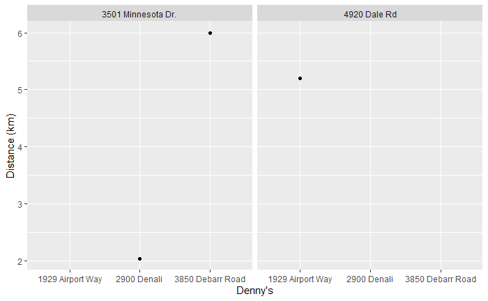

```r
ggplot(dn_lq_ak_mindist, aes(address.x, closest))+
  geom_line(color="steelblue")+
  geom_point()+
  facet_wrap(vars(address.y))+
labs(
  x="Denny's",
  y="Distance (km)"
)
```

### Prepping the Data

```r
laquinta %>%
  filter(!(state %in% states$abbreviation))
```

| address | city | state | zip | longitude | latitude | country | establishment |
| --- | --- | --- | --- | --- | --- | --- | --- |
| Carretera Panamericana Sur KM 12 | \nAguascalientes | AG | 20345 | -102.27633 | 21.755585 | Mexico | La Quinta |
| Av. Tulum Mza. 14 S.M. 4 Lote 2 | \nCancun | QR | 77500 | -86.82462 | 21.151911 | Mexico | La Quinta |
| Ejercito Nacional 8211 | Col\nPartido Iglesias\nJuarez | CH | 32528 | -106.41015 | 31.697130 | Mexico | La Quinta |
| Blvd. Aeropuerto 4001 | Parque Industrial Interamerican\nApodaca | NL | 66600 | -100.14050 | 25.788750 | Mexico | La Quinta |
| Carrera 38 # 26-13 Avenida las Palmas con Loma de San Julian El Poblado | \nMedellin Colombia | ANT | 050016 | -75.56551 | 6.224831 | Colombia | La Quinta |
| AV. PINO SUAREZ No. 1001 | Col. Centro\nMonterrey | NL | 64000 | -100.32011 | 25.666541 | Mexico | La Quinta |
| Av. Fidel Velazquez #3000 Col. Central | \nMonterrey | NL | 64190 | -100.33770 | 25.720653 | Mexico | La Quinta |
| 63 King Street East | \nOshawa | ON | L1H1B4 | -78.86126 | 43.898034 | Canada | La Quinta |
| Calle Las Torres-1 Colonia Reforma | \nPoza Rica | VE | 93210 | -97.43758 | 20.564131 | Mexico | La Quinta |
| Blvd. Audi N. 3 Ciudad Modelo | \nSan Jose Chiapa | PU | 75010 | -97.78146 | 19.226297 | Mexico | La Quinta |

[output cut: 4 more lines]

```r
dennys %>%
  filter(!(state %in% states$abbreviation))
```

| address | city | state | zip | longitude | latitude | country | establishment |
| --- | --- | --- | --- | --- | --- | --- | --- |

```r
dennys %>%
  mutate(country = "United States")
```

| address | city | state | zip | longitude | latitude | country | establishment |
| --- | --- | --- | --- | --- | --- | --- | --- |
| 2900 Denali | Anchorage | AK | 99503 | -149.8767 | 61.1953 | United States | Denny's |
| 3850 Debarr Road | Anchorage | AK | 99508 | -149.8090 | 61.2097 | United States | Denny's |
| 1929 Airport Way | Fairbanks | AK | 99701 | -147.7600 | 64.8366 | United States | Denny's |
| 230 Connector Dr | Auburn | AL | 36849 | -85.4681 | 32.6033 | United States | Denny's |
| 224 Daniel Payne Drive N | Birmingham | AL | 35207 | -86.8317 | 33.5615 | United States | Denny's |
| 900 16th St S, Commons on Gree | Birmingham | AL | 35294 | -86.8037 | 33.5007 | United States | Denny's |
| 5931 Alabama Highway, #157 | Cullman | AL | 35056 | -86.8722 | 34.2068 | United States | Denny's |
| 2190 Ross Clark Circle | Dothan | AL | 36301 | -85.4006 | 31.1904 | United States | Denny's |
| 900 Tyson Rd | Hope Hull (Tyson) | AL | 36043 | -86.4209 | 32.1953 | United States | Denny's |
| 4874 University Drive | Huntsville | AL | 35816 | -86.6556 | 34.7379 | United States | Denny's |

[output cut: 990 more lines]

```r
dennys <- dennys %>%
  mutate(dennys, country = case_when(
    state %in% state.abb  ~ "United States",
  state=="DC" ~ "United States"))
laquinta <- laquinta %>%
  mutate(laquinta, country = case_when(
    state %in% state.abb  ~ "United States",
    state %in% c("ON", "BC") ~ "Canada",
    state == "ANT" ~ "Colombia",
    state %in% c("AG", "QR", "CH", "NL", "VE", "PU", "SL") ~ "Mexico",
    state == "FM" ~ "Honduras"
  ))
```

### Exercise 9

Repeated the same analysis for North Carolina:

1. Filtered Denny’s and La Quinta Data Frames for NC.
2. Joined these data frames to get a complete list of all possible pairings.
3. Calculated the distances between all possible pairings of Denny’s and La Quinta in NC.
4. Found the minimum distance between each Denny’s and La Quinta location.
5. Visualize and describe the distribution of these shortest distances using appropriate summary statistics.

```r
dennys_nc = dennys %>%
filter(state=="NC")%>%
mutate(establishment = "Denny's")
laquinta_nc = laquinta %>%
  filter(state=="NC")%>%
  mutate(establishment = "La Quinta")
dn_lq_nc <- full_join(dennys_nc, laquinta_nc, by = "state")

dn_lq_nc %<>%
  mutate(distance = haversine(longitude.x, latitude.x, longitude.y, latitude.y))%>%
arrange(distance)

dn_lq_nc_mindist = dn_lq_nc %>%
  select(address.x, address.y, distance)%>%
  group_by(address.x, address.y) %>%
  summarise(closest = min(distance))%>%
  filter(closest<=10)%>%
  arrange(closest)
dn_lq_nc_mindist
```

| address.x | address.y | closest |
| --- | --- | --- |
| 516 Tyvola Rd | 4900 South Tryon St | 1.779 |
| 3215 Wake Forest Rd | 2211 Summit Park Ln | 5.044 |
| 7021 Highway 751, #901 | 4414 Durham Chapel Hill Blvd | 5.064 |
| 7021 Highway 751, #901 | 1910 Westpark Dr | 6.296 |
| 516 Tyvola Rd | 3127 Sloan Dr | 9.165 |
| 4541 Sunset Rd | 3127 Sloan Dr | 9.685 |

### Exercise 10

Repeated the same analysis for Texas.

```r
dennys_tx = dennys %>%
filter(state=="TX")%>%
mutate(establishment = "Denny's")
laquinta_tx = laquinta %>%
  filter(state=="TX")%>%
  mutate(establishment = "La Quinta")
dn_lq_tx <- full_join(dennys_tx, laquinta_tx, by = "state")

dn_lq_tx%<>%
  mutate(distance = haversine(longitude.x, latitude.x, longitude.y, latitude.y))%>%
arrange(distance)

dn_lq_tx_mindist = dn_lq_tx %>%
  select(address.x, address.y, distance)%>%
  group_by(address.x, address.y) %>%
  summarise(closest = min(distance))%>%
  filter(closest<=10)%>%
  arrange(closest)
dn_lq_tx_mindist
```

| address.x | address.y | closest |
| --- | --- | --- |
| 607 Avenue Q | 601 Ave Q | 0.016 |
| 1410 Seawall Blvd | 1402 Seawall Blvd | 0.026 |
| 3600 Santa Ursula | 3610 Santa Ursula Ave | 0.027 |
| 7619 E Ben White Boulevard | 7625 East Ben White Blvd | 0.034 |
| 28669 I-45 North | 28673 I-45 North | 0.037 |
| 1108 S Fort Hood Rd | 1112 South Fort Hood St | 0.042 |
| 2951 State Hwy 36 South | 2950 Wood Ridge Blvd | 0.056 |
| 11045 Gateway W | 11033 Gateway Blvd West | 0.057 |
| 4115 West Airport | 4105 West Airport Fwy | 0.062 |
| 1710 I-40 East | 1708 Interstate 40 East | 0.066 |

[output cut: 394 more lines]

### Exercise 11

Repeated the same analysis for New York.

```r
dennys_ny = dennys %>%
filter(state=="NY")%>%
mutate(establishment = "Denny's")
laquinta_ny = laquinta %>%
  filter(state=="NY")%>%
  mutate(establishment = "La Quinta")
dn_lq_ny <- full_join(dennys_ny, laquinta_ny, by = "state")

dn_lq_ny%<>%
  mutate(distance = haversine(longitude.x, latitude.x, longitude.y, latitude.y))%>%
arrange(distance)

dn_lq_ny_mindist = dn_lq_ny %>%
   select(address.x, address.y, distance)%>%
  group_by(address.x, address.y) %>%
  summarise(closest = min(distance))%>%
  filter(closest<=10)%>%
  arrange(closest)
dn_lq_ny_mindist
```

| address.x | address.y | closest |
| --- | --- | --- |
| 371 Old Country Road | 821 Stewart Ave | 1.281 |
| 697 Troy-Schenectady Rd | 833 New Loudon Rd | 1.391 |
| 364 W Main St | 8200 Park Road | 1.598 |
| 8020 Niagara Falls | 6225 Niagara Falls Blvd | 1.737 |
| 4610 Genesee St | 6619 Transit Rd | 2.131 |
| 805 Pennsylvania Ave | 1412 Pitkin Ave | 2.890 |
| 4024 Vestal Parkway East | 581 Harry L. Dr | 3.252 |
| 8710 Northern Blvd | 37-18 Queens Blvd | 4.229 |
| 150 Nassau St | 17 West 32nd St | 4.330 |
| 150 Nassau St | 533 3rd Ave | 4.855 |

[output cut: 16 more lines]

### Exercise 12

Among the states you examined, where is Mitch Hedberg’s joke most likely to hold true? Explain your reasoning.

We can see that various Denny’s and La Quinta locations in Texas are very close. In Texas there are 39 pairs of Denny’s and La Quinta that are less than 0.5 km further from each other and various others that are 1-10 km away from each other. Thus the joke is most likely to hold true for Texas because the corresponding Denny’s and La Quinta locations are very close to one another compared to any other states.

New York also has various locations that are 1-2 km away.

For Alaska, we have only 3 locations (with respect to Denny’s) that are closer to each other (Denny’s and La Quinta).